**Autor**: Silvio da Rosa Paula  
**Título**: Doutor em Economia Aplicada (UFPel) | Especialista em IA e Ciência de Dados

# Endogeneidade na Prática: Por que a Regressão Linear (MQO) Falha na Precificação e Como Variáveis Instrumentais (IV / 2SLS) Corrigem o Problema

## 1. Introdução: O Problema Clássico da Elasticidade-Preço

Uma das perguntas mais valiosas para qualquer empresa é:

> **"Se eu aumentar o preço do meu produto em 10%, quanto as minhas vendas vão cair? E a minha receita total vai subir ou descer?"**

A resposta depende da **Elasticidade-Preço da Demanda ($\varepsilon$)** — um número que mede a sensibilidade percentual das vendas a uma variação de 1% no preço:

- **Demanda Inelástica ($|\varepsilon| < 1$, ex.: $-0,70$)**: O consumidor é pouco sensível ao preço. Se você subir o preço em 10%, as vendas caem apenas ~7% e a **receita total SOBE**.
- **Demanda Elástica ($|\varepsilon| > 1$, ex.: $-1,80$)**: O consumidor é muito sensível ao preço. Se você subir o preço em 10%, as vendas despencam ~18% e a **receita total CAI**.

### Mas por que a regressão linear comum (MQO / OLS) quase sempre erra esse cálculo?

O vilão se chama **Endogeneidade (Simultaneidade)**.

No mundo real, as empresas não sorteiam preços aleatoriamente! Quando há um **choque de demanda não observado** (por exemplo: um feriado surpresa, um produto que viralizou nas redes sociais ou uma onda de calor para venda de sorvetes), **duas coisas acontecem ao mesmo tempo**:

1. As **vendas disparam** por causa da alta demanda.
2. Percebendo a procura aquecida, a empresa **aumenta o preço** (ou reduz descontos).

Quando jogamos esses dados históricos em uma regressão linear comum (**MQO / OLS**), o modelo vê *"preços mais altos acontecendo junto com vendas altas"* e fica confuso! Ele mistura o **efeito real do preço** (que derruba vendas) com o **choque de demanda** (que puxa preço e vendas para cima). O resultado é uma **elasticidade drasticamente subestimada (viés para cima)**.

## 2. A Solução: Variáveis Instrumentais (IV / 2SLS)

Para quebrar essa confusão, precisamos de uma **Variável Instrumental ($Z$)** — algo que funcione como um "experimento natural" escondido nos dados.

No mercado de bens e serviços, o instrumento econômico clássico para o preço é um **choque de custo de oferta** (por exemplo, o **preço internacional de uma matéria-prima / custo de insumo** ou um **custo de frete exógeno**).

Para que `custo_insumo` ($Z$) seja um instrumento válido, ele precisa cumprir **duas regras de ouro**:

1. **Relevância ($\text{Cov}(Z, \text{Preço}) \neq 0$)**: Quando o custo da matéria-prima sobe, a empresa repassa parte desse custo para o preço final do produto. *(Podemos testar isso nos dados usando a Estatística F do 1º Estágio).*
2. **Restrição de Exclusão ($\text{Cov}(Z, \varepsilon_{\text{demanda}}) = 0$)**: O custo da matéria-prima **não** altera o desejo do consumidor diretamente — o cliente no supermercado ou no e-commerce só reage ao custo **através do preço final** que ele vê na prateleira.

Com isso, o método de **Mínimos Quadrados em Dois Estágios (2SLS / IV)** isola apenas a parte "limpa" (exógena) do preço que variou por causa do custo, recuperando a verdadeira elasticidade-preço causal!

## 3. Preparando o Ambiente em Python

Vamos carregar as bibliotecas necessárias para o nosso passo a passo:

- `numpy` e `pandas`: geração e manipulação da base simulada.
- `statsmodels`: estimação do modelo **MQO (OLS)** e demonstração manual dos dois estágios do 2SLS.
- `linearmodels`: biblioteca padrão de econometria em Python para rodar **IV / 2SLS** (`IV2SLS`) com erros-padrão exatos e diagnósticos formais (**Teste F de Instrumentos Fracos** e **Teste de Wu-Hausman**).
- `matplotlib` e `seaborn`: visualizações claras para comparar MQO vs. IV.

```python
import warnings
import numpy as np
import pandas as pd
import statsmodels.api as sm
import statsmodels.formula.api as smf
from linearmodels.iv import IV2SLS
from sklearn.metrics import root_mean_squared_error, mean_absolute_error, mean_absolute_percentage_error
import matplotlib.pyplot as plt
import seaborn as sns

warnings.filterwarnings("ignore")
pd.options.display.float_format = "{:.4f}".format
sns.set_theme(style="whitegrid")
plt.rcParams["figure.dpi"] = 110

print("Bibliotecas carregadas com sucesso!")
```

```
Bibliotecas carregadas com sucesso!
```

## 4. Passo 1: Simulando um Mercado com Endogeneidade Conhecida

### O que vamos fazer agora e por quê?

Na prática, nunca conhecemos a elasticidade-preço verdadeira de um produto. Por isso, vamos construir um **mercado simulado de 500 dias**, no qual **nós mesmos definimos a verdade** para poder testar qual modelo (MQO ou IV) acerta o alvo:

- **Elasticidade-Preço Verdadeira ($\beta_{\text{verdadeiro}}$)**: **`-1,80`** (um aumento de 1% no preço derruba as vendas em 1,80% — **demanda altamente elástica**).
- **Variáveis de Controle Exógenas**:
  - `log_renda`: renda média dos consumidores (elasticidade-renda verdadeira = **`+0,50`**).
  - `sazonalidade`: ciclo sazonal anual (efeito verdadeiro = **`+0,20`**).
- **O Vilão (Endogeneidade)**: Criamos uma variável **`choque_demanda`** (não observada pelo analista na hora de estimar o modelo!). Ela entra **tanto na equação de Vendas (`+1,0 * choque_demanda`) quanto na equação de Preço (`+0,80 * choque_demanda`)**, simulando o comportamento real da empresa que sobe preços quando a procura esquenta.
- **O Instrumento (`log_custo`)**: Criamos o custo da matéria-prima, que afeta diretamente o preço (`+0,65 * log_custo`), mas **não entra** na equação de demanda (satisfazendo a restrição de exclusão).

```python
# Fixamos a semente para 100% de reprodutibilidade
np.random.seed(456)

n = 500  # 500 dias de operação do mercado
datas = pd.date_range(start="2020-01-01", periods=n, freq="D")
tempo = np.arange(1, n + 1)

# 1. Variáveis exógenas observadas pelo analista
renda = np.random.normal(50, 10, size=n)
sazonalidade = np.sin(2 * np.pi * tempo / 365)

# 2. Instrumento exógeno (custo da matéria-prima / frete que muda ao longo do tempo)
custo_insumo = np.exp(3.0 + 0.25 * np.random.normal(0, 1, size=n))
log_custo = np.log(custo_insumo)

# 3. O VILÃO: Choque de demanda NÃO observado pelo analista (ex: clima, viralização)
choque_demanda = np.random.normal(0, 0.5, size=n)

# 4. Equação do PREÇO (Oferta/Precificação):
#    Note que o preço sobe quando o custo sobe (+0.65) E TAMBÉM quando há choque de demanda (+0.80 -> ENDOGENEIDADE!)
log_preco = (
    2.5
    + 0.65 * log_custo
    + 0.80 * choque_demanda
    + 0.10 * sazonalidade
    + np.random.normal(0, 0.08, size=n)
)
preco = np.exp(log_preco)

# 5. Equação das VENDAS (Demanda):
#    A ELASTICIDADE-PREÇO VERDADEIRA é exatamente -1.80!
#    Note que 'log_custo' NÃO aparece aqui (restrição de exclusão), mas 'choque_demanda' SIM!
ELASTICIDADE_VERDADEIRA = -1.80
log_renda = np.log(renda)

log_vendas = (
    6.0
    + ELASTICIDADE_VERDADEIRA * log_preco
    + 0.50 * log_renda
    + 0.20 * sazonalidade
    + 1.00 * choque_demanda
    + np.random.normal(0, 0.10, size=n)
)
vendas = np.exp(log_vendas)

# Montagem do DataFrame final
dados = pd.DataFrame({
    "data": datas,
    "preco": preco,
    "vendas": vendas,
    "renda": renda,
    "custo_insumo": custo_insumo,
    "sazonalidade": sazonalidade,
    "log_vendas": log_vendas,
    "log_preco": log_preco,
    "log_renda": log_renda,
    "log_custo": log_custo,
    "choque_demanda": choque_demanda  # Guardado apenas para fins didáticos de diagnóstico!
})

print(f"Base simulada com sucesso: {len(dados)} dias de histórico.")
display(dados[["data", "preco", "vendas", "custo_insumo", "renda", "sazonalidade"]].head())
```

```
Base simulada com sucesso: 500 dias de histórico.
```

|  | data | preco | vendas | custo_insumo | renda | sazonalidade |
| --- | --- | --- | --- | --- | --- | --- |
| 0 | 2020-01-01 | 104.1055 | 0.8481 | 16.6353 | 43.3187 | 0.0172 |
| 1 | 2020-01-02 | 122.7058 | 0.5597 | 21.2518 | 45.0179 | 0.0344 |
| 2 | 2020-01-03 | 150.8147 | 0.5904 | 26.7689 | 56.1858 | 0.0516 |
| 3 | 2020-01-04 | 67.3979 | 1.4782 | 15.7603 | 55.6869 | 0.0688 |
| 4 | 2020-01-05 | 141.5547 | 0.5095 | 23.1636 | 63.5051 | 0.0860 |

## 5. Passo 2: Enxergando a Endogeneidade nas Correlações

### O que vamos fazer agora e por quê?

Como nós construímos a simulação, temos o "privilégio divino" de olhar para a variável oculta `choque_demanda` (que na vida real fica escondida dentro do erro da regressão) e verificar as correlações. Isso vai provar visualmente:

1. Por que `log_preco` é **endógeno** (correlacionado com `choque_demanda`).
2. Por que `log_custo` é um **ótimo instrumento** (correlacionado com `log_preco`, mas com correlação próxima de zero com `choque_demanda`).

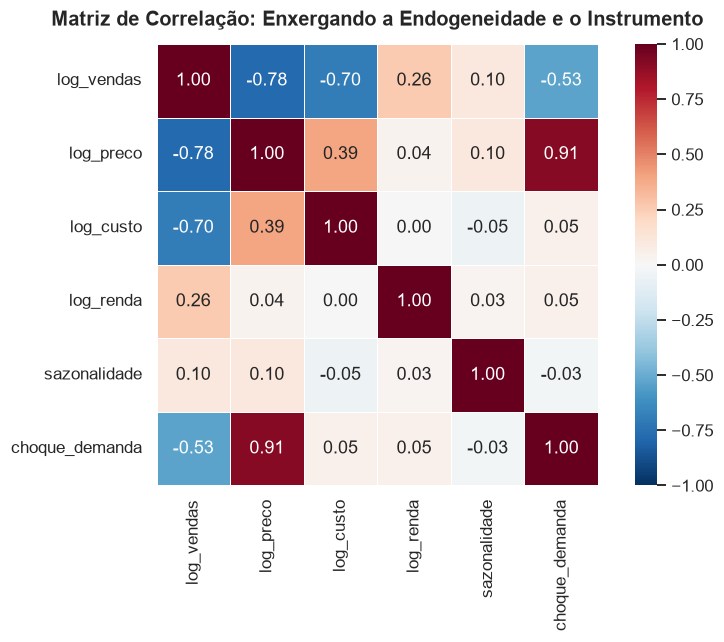

```
• Correlação (log_preco vs. choque_demanda) [PROBLEMA - Endogeneidade] : +0.908
• Correlação (log_custo vs. log_preco)      [REGRA 1 - Relevância]     : +0.394
• Correlação (log_custo vs. choque_demanda) [REGRA 2 - Exogeneidade]   : +0.052
```

```python
cols_corr = ["log_vendas", "log_preco", "log_custo", "log_renda", "sazonalidade", "choque_demanda"]
corr_matrix = dados[cols_corr].corr()

fig, ax = plt.subplots(figsize=(8, 6))
sns.heatmap(
    corr_matrix, annot=True, fmt=".2f", cmap="RdBu_r",
    center=0, vmin=-1, vmax=1, square=True, linewidths=0.5, ax=ax
)
ax.set_title("Matriz de Correlação: Enxergando a Endogeneidade e o Instrumento", fontsize=13, fontweight="bold", pad=12)
plt.tight_layout()
plt.show()

print(f"• Correlação (log_preco vs. choque_demanda) [PROBLEMA - Endogeneidade] : {corr_matrix.loc['log_preco', 'choque_demanda']:+.3f}")
print(f"• Correlação (log_custo vs. log_preco)      [REGRA 1 - Relevância]     : {corr_matrix.loc['log_custo', 'log_preco']:+.3f}")
print(f"• Correlação (log_custo vs. choque_demanda) [REGRA 2 - Exogeneidade]   : {corr_matrix.loc['log_custo', 'choque_demanda']:+.3f}")
```

### Como interpretar esse mapa de correlações?

Olhe os três números destacados logo abaixo do gráfico:

1. **A prova do crime (`log_preco` vs. `choque_demanda` = `+0,91`)**: O preço tem uma correlação fortíssima com o choque de demanda não observado! Isso viola completamente a premissa central do MQO ($E[\varepsilon \mid X] = 0$).
2. **A força do instrumento (`log_custo` vs. `log_preco` = `+0,39`)**: Quando o custo do insumo sobe, o preço final sobe junto (Regra 1: Relevância atendida).
3. **A limpeza do instrumento (`log_custo` vs. `choque_demanda` = `+0,05`)**: O custo do insumo é estatisticamente independente do choque de demanda (Regra 2: Exogeneidade atendida).

## 6. Passo 3: Estimando o Modelo Ingênuo (MQO / OLS)

### O que vamos fazer agora e por quê?

Vamos estimar a regressão linear tradicional (**MQO / OLS**), exatamente como a maioria das pessoas faz no dia a dia quando não trata a endogeneidade: $$\log(\text{vendas}) = \beta_0 + \beta_1 \log(\text{preço}) + \beta_2 \log(\text{renda}) + \beta_3 \text{sazonalidade} + \varepsilon$$

Vamos observar o quão longe o coeficiente $\hat{\beta}_1$ vai passar do valor verdadeiro (`-1,80`).

```python
# Estimação tradicional por Mínimos Quadrados Ordinários (MQO / OLS)
modelo_ols = smf.ols("log_vendas ~ log_preco + log_renda + sazonalidade", data=dados).fit()

resumo_ols = pd.DataFrame({
    "Coeficiente Estimado": modelo_ols.params,
    "Erro-Padrão": modelo_ols.bse,
    "Estatística t": modelo_ols.tvalues,
    "P-Valor": modelo_ols.pvalues
})

print("RESULTADOS DO MODELO MQO (OLS) — IGNORANDO ENDOGENEIDADE:")
display(resumo_ols)
print(f"• R² do modelo MQO: {modelo_ols.rsquared:.4f}")
print(f"• Elasticidade-Preço Verdadeira : {ELASTICIDADE_VERDADEIRA:.4f}")
print(f"• Elasticidade-Preço MQO (OLS)  : {modelo_ols.params['log_preco']:.4f}")
vies_ols = modelo_ols.params["log_preco"] - ELASTICIDADE_VERDADEIRA
print(f"• ERRO / VIÉS DO MQO            : {vies_ols:+.4f} (Subestimou a elasticidade em {abs(vies_ols)/abs(ELASTICIDADE_VERDADEIRA)*100:.1f}%!)")
```

```
RESULTADOS DO MODELO MQO (OLS) — IGNORANDO ENDOGENEIDADE:
```

|  | Coeficiente Estimado | Erro-Padrão | Estatística t | P-Valor |
| --- | --- | --- | --- | --- |
| Intercept | 1.2122 | 0.2072 | 5.8496 | 0.0000 |
| log_preco | -0.7735 | 0.0232 | -33.3817 | 0.0000 |
| log_renda | 0.5577 | 0.0469 | 11.8988 | 0.0000 |
| sazonalidade | 0.1055 | 0.0143 | 7.3716 | 0.0000 |

```
• R² do modelo MQO: 0.7159
• Elasticidade-Preço Verdadeira : -1.8000
• Elasticidade-Preço MQO (OLS)  : -0.7735
• ERRO / VIÉS DO MQO            : +1.0265 (Subestimou a elasticidade em 57.0%!)
```

### O Desastre do MQO Explicado:

Olhe para a tabela acima:

- **O MQO parece perfeito à primeira vista**: $R^2$ alto (`0,7159`), todos os p-valores altamente significativos ($p < 0,001$), sinal negativo para preço e positivo para renda.
- **Mas o resultado é uma armadilha brutal**: O MQO estimou uma elasticidade-preço de **`-0,7735`** quando a verdade é **`-1,8000`** — um erro de **57,0%**!
- **Pior ainda**: O MQO mudou a classificação econômica do produto! Ele faz a empresa acreditar que a demanda é **inelástica** ($|\varepsilon| < 1$), quando na realidade ela é **fortemente elástica** ($|\varepsilon| > 1$).

## 7. Passo 4: Entendendo o 2SLS (Variáveis Instrumentais) "Por Dentro"

### O que vamos fazer agora e por quê?

Muitas pessoas usam o método de Variáveis Instrumentais como uma "caixa-preta". Para entender de verdade como ele corrige o viés do MQO, o nome **2SLS (*Two-Stage Least Squares* — Mínimos Quadrados em Dois Estágios)** já entrega o segredo:

1. **1º Estágio (Limpeza do Preço)**: Regredimos o `log_preco` contra o nosso instrumento (`log_custo`) e as variáveis de controle (`log_renda`, `sazonalidade`). O valor previsto dessa regressão (`log_preco_limpo`) captura **apenas a variação do preço causada pelo custo**, jogando fora a parte contaminada pelo choque de demanda!
   - *Regra de diagnóstico*: Checamos a **Estatística F** do instrumento no 1º Estágio. Pela regra clássica de Staiger & Stock (1997), queremos **$F > 10$** para garantir que o instrumento é forte.
2. **2º Estágio (Estimação Causal com `IV2SLS`)**: Substituímos o preço contaminado pelo preço limpo para estimar a elasticidade-preço real!
   - *Nota técnica importante*: Rodamos a biblioteca `linearmodels.iv.IV2SLS` no 2º estágio porque fazer o 2º estágio manualmente no OLS acerta o coeficiente pontual, mas calcula os erros-padrão incorretos. O `IV2SLS` calcula os erros-padrão corretos e entrega o **Teste de Wu-Hausman** (que prova estatisticamente a presença de endogeneidade).

```python
# =============================================================================
# 1º ESTÁGIO (INSPEÇÃO DIDÁTICA): ISOLANDO A VARIAÇÃO LIMPA DO PREÇO
# =============================================================================
primeiro_estagio = smf.ols("log_preco ~ log_custo + log_renda + sazonalidade", data=dados).fit()

# Teste F específico para o instrumento 'log_custo'
f_instrumento = primeiro_estagio.f_test("log_custo = 0")
f_stat = float(f_instrumento.fvalue)
f_pval = float(f_instrumento.pvalue)

print("=== 1º ESTÁGIO: QUANTO O CUSTO EXPLICA O PREÇO? ===")
print(f"• Coeficiente de log_custo no preço : {primeiro_estagio.params['log_custo']:.4f} (p-valor = {primeiro_estagio.pvalues['log_custo']:.2e})")
print(f"• Estatística F do Instrumento      : {f_stat:.2f} (Referência: F > 10 indica instrumento FORTE)")
print(f"• Diagnóstico de Relevância         : {'INSTRUMENTO FORTE (Aprovado!)' if f_stat > 10 else 'Instrumento Fraco'}")

# =============================================================================
# 2º ESTÁGIO FORMAL: ESTIMAÇÃO IV / 2SLS COM LINEARMODELS
# =============================================================================
# Fórmula no padrão linearmodels: y ~ exógenas + [endógena ~ instrumento]
modelo_iv = IV2SLS.from_formula(
    "log_vendas ~ 1 + log_renda + sazonalidade + [log_preco ~ log_custo]",
    data=dados
).fit(cov_type="robust")

resumo_iv = pd.DataFrame({
    "Coeficiente Estimado": modelo_iv.params,
    "Erro-Padrão (Robusto)": modelo_iv.std_errors,
    "Estatística t": modelo_iv.tstats,
    "P-Valor": modelo_iv.pvalues
})

print("\n=== 2º ESTÁGIO (IV / 2SLS): ELASTICIDADE CAUSAL CORRIGIDA ===")
display(resumo_iv)

# Diagnóstico de Endogeneidade (Teste de Wu-Hausman)
wu_hausman = modelo_iv.wu_hausman()
print("=== TESTE DE WU-HAUSMAN (DIAGNÓSTICO DE ENDOGENEIDADE) ===")
print(f"• Estatística Wu-Hausman : {wu_hausman.stat:.2f}")
print(f"• P-Valor                : {wu_hausman.pval:.2e}")
print("• Interpretação          : Rejeitamos H0 de exogeneidade (p < 0,001). O preço É endógeno e o uso de IV é indispensável!")
```

```
=== 1º ESTÁGIO: QUANTO O CUSTO EXPLICA O PREÇO? ===
• Coeficiente de log_custo no preço : 0.7228 (p-valor = 9.37e-21)
• Estatística F do Instrumento      : 95.55 (Referência: F > 10 indica instrumento FORTE)
• Diagnóstico de Relevância         : INSTRUMENTO FORTE (Aprovado!)

=== 2º ESTÁGIO (IV / 2SLS): ELASTICIDADE CAUSAL CORRIGIDA ===
```

|  | Coeficiente Estimado | Erro-Padrão (Robusto) | Estatística t | P-Valor |
| --- | --- | --- | --- | --- |
| Intercept | 5.0487 | 0.6190 | 8.1563 | 0.0000 |
| log_renda | 0.6167 | 0.0975 | 6.3283 | 0.0000 |
| sazonalidade | 0.1635 | 0.0297 | 5.5023 | 0.0000 |
| log_preco | -1.6824 | 0.1147 | -14.6722 | 0.0000 |

```
=== TESTE DE WU-HAUSMAN (DIAGNÓSTICO DE ENDOGENEIDADE) ===
• Estatística Wu-Hausman : 735.11
• P-Valor                : 1.11e-16
• Interpretação          : Rejeitamos H0 de exogeneidade (p < 0,001). O preço É endógeno e o uso de IV é indispensável!
```

## 8. Passo 5: Comparação Direta — Verdade vs. MQO (OLS) vs. IV (2SLS)

Vamos colocar os resultados lado a lado em uma tabela e em um gráfico de dispersão para enxergar visualmente como a reta do MQO fica "achatada" (menos inclinada) pela endogeneidade, enquanto a reta do IV recupera a inclinação real da curva de demanda.

|  | Modelo | Elasticidade-Preço | Viés Absoluto | Erro Relativo (%) | Classificação Econômica |
| --- | --- | --- | --- | --- | --- |
| 0 | Verdadeiro (Simulação) | -1.8000 | 0.0000 | 0,0% | Demanda Elástica (\|ε\| > 1) |
| 1 | MQO / OLS (Enviesado) | -0.7735 | 1.0265 | 57.0% | Demanda Inelástica (\|ε\| < 1) — ERRADO! |
| 2 | IV / 2SLS (Corrigido) | -1.6824 | 0.1176 | 6.5% | Demanda Elástica (\|ε\| > 1) — CORRETO! |

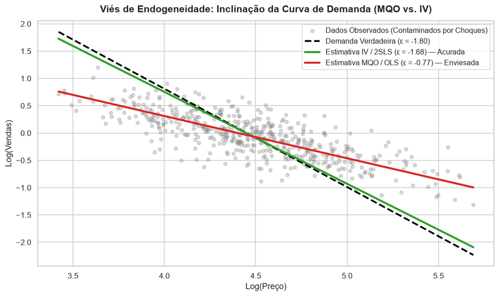

```python
elast_ols = modelo_ols.params["log_preco"]
elast_iv  = modelo_iv.params["log_preco"]

comparacao_elast = pd.DataFrame({
    "Modelo": ["Verdadeiro (Simulação)", "MQO / OLS (Enviesado)", "IV / 2SLS (Corrigido)"],
    "Elasticidade-Preço": [ELASTICIDADE_VERDADEIRA, elast_ols, elast_iv],
    "Viés Absoluto": [0.0, elast_ols - ELASTICIDADE_VERDADEIRA, elast_iv - ELASTICIDADE_VERDADEIRA],
    "Erro Relativo (%)": [
        "0,0%",
        f"{abs(elast_ols - ELASTICIDADE_VERDADEIRA)/abs(ELASTICIDADE_VERDADEIRA)*100:.1f}%",
        f"{abs(elast_iv - ELASTICIDADE_VERDADEIRA)/abs(ELASTICIDADE_VERDADEIRA)*100:.1f}%"
    ],
    "Classificação Econômica": [
        "Demanda Elástica (|ε| > 1)",
        "Demanda Inelástica (|ε| < 1) — ERRADO!",
        "Demanda Elástica (|ε| > 1) — CORRETO!"
    ]
})

display(comparacao_elast)

# Visualização gráfica das retas de demanda (controlando por renda e sazonalidade na média)
fig, ax = plt.subplots(figsize=(10, 6))

# Dispersão dos dados observados
ax.scatter(dados["log_preco"], dados["log_vendas"], alpha=0.30, color="gray", s=25, label="Dados Observados (Contaminados por Choques)")

# Eixo x para traçar as 3 inclinações passando pelo ponto médio
x_grid = np.linspace(dados["log_preco"].min(), dados["log_preco"].max(), 100)
x_mean = dados["log_preco"].mean()
y_mean = dados["log_vendas"].mean()

y_true_line = y_mean + ELASTICIDADE_VERDADEIRA * (x_grid - x_mean)
y_ols_line  = y_mean + elast_ols * (x_grid - x_mean)
y_iv_line   = y_mean + elast_iv * (x_grid - x_mean)

ax.plot(x_grid, y_true_line, color="black", linestyle="--", linewidth=2.5, label=f"Demanda Verdadeira (ε = {ELASTICIDADE_VERDADEIRA:.2f})")
ax.plot(x_grid, y_iv_line,   color="#2ca02c", linewidth=2.8, label=f"Estimativa IV / 2SLS (ε = {elast_iv:.2f}) — Acurada")
ax.plot(x_grid, y_ols_line,  color="#d62728", linewidth=2.8, label=f"Estimativa MQO / OLS (ε = {elast_ols:.2f}) — Enviesada")

ax.set_title("Viés de Endogeneidade: Inclinação da Curva de Demanda (MQO vs. IV)", fontsize=14, fontweight="bold", pad=12)
ax.set_xlabel("Log(Preço)", fontsize=12)
ax.set_ylabel("Log(Vendas)", fontsize=12)
ax.legend(frameon=True, fontsize=10.5)

plt.tight_layout()
plt.show()
```

### O que o gráfico acima deixa cristalino?

- **Linha Vermelha (MQO / OLS)**: Fica muito mais "deitada" (`-0,77`) porque os pontos no topo superior direito (preço alto + venda alta causados pelo choque de demanda) puxam a inclinação da reta para cima!
- **Linha Verde (IV / 2SLS)**: Fica praticamente colada em cima da linha preta tracejada da **Demanda Verdadeira** (`-1,80`), estimando **`-1,68`** (erro de apenas 6,5%) e eliminando quase todo o viés de endogeneidade!

## 9. Passo 6: O Paradoxo "Previsão (RMSE) vs. Decisão de Preço (Causalidade)"

### Por que o MQO tem erro de previsão (RMSE) MENOR nos dados históricos, mas QUEBRA a empresa na hora de mudar o preço?

Essa é uma das lições mais importantes da Econometria Aplicada para Cientistas de Dados. Vamos calcular **duas coisas** abaixo:

1. **Desempenho Preditivo Histórico (RMSE, MAE e $R^2$)** nos 500 dias passados.
2. **Simulação Contrafactual de Negócio (*Pricing*)**: Imagine que amanhã a diretoria decida **aumentar o preço em +10%** (sem nenhum choque de demanda extra). Vamos comparar o que o **MQO** promete que vai acontecer com a **Receita Total**, o que o **IV** prevê, e o que **realmente acontece**!

```python
# 1. Métricas de previsão nos dados históricos (escala original de vendas)
pred_vendas_ols = np.exp(modelo_ols.predict(dados))
pred_vendas_iv  = np.exp(modelo_iv.predict(data=dados)["predictions"])

metricas_historicas = pd.DataFrame({
    "Modelo": ["MQO / OLS (Enviesado)", "IV / 2SLS (Corrigido)"],
    "RMSE (Vendas)": [
        root_mean_squared_error(dados["vendas"], pred_vendas_ols),
        root_mean_squared_error(dados["vendas"], pred_vendas_iv)
    ],
    "MAE (Vendas)": [
        mean_absolute_error(dados["vendas"], pred_vendas_ols),
        mean_absolute_error(dados["vendas"], pred_vendas_iv)
    ],
    "MAPE (%)": [
        mean_absolute_percentage_error(dados["vendas"], pred_vendas_ols) * 100,
        mean_absolute_percentage_error(dados["vendas"], pred_vendas_iv) * 100
    ]
})

print("1. DESEMPENHO PREDITIVO NO PASSADO (QUANDO NINGUÉM INTERVÉM NO PREÇO):")
display(metricas_historicas)

# 2. SIMULAÇÃO CONTRAFACTUAL: AUMENTO DE +10% NO PREÇO (DECISÃO DE PRICING)
# Fórmula exata em modelo log-log: novo_volume / volume_base = (1.10 ^ elasticidade)
# Nova receita / receita_base = 1.10 * (1.10 ^ elasticidade) = 1.10 ^ (1 + elasticidade)
aumento_preco = 0.10  # +10%

def impacto_pricing(elast, delta_p=0.10):
    var_vendas_pct  = ((1 + delta_p) ** elast - 1) * 100
    var_receita_pct = ((1 + delta_p) ** (1 + elast) - 1) * 100
    return var_vendas_pct, var_receita_pct

v_real, r_real = impacto_pricing(ELASTICIDADE_VERDADEIRA, aumento_preco)
v_ols,  r_ols  = impacto_pricing(elast_ols, aumento_preco)
v_iv,   r_iv   = impacto_pricing(elast_iv, aumento_preco)

tabela_pricing = pd.DataFrame({
    "Cenário (Aumento de +10% no Preço)": [
        "Previsão do MQO / OLS (Enviesado)",
        "Previsão do IV / 2SLS (Corrigido)",
        "REALIDADE DO MERCADO (Verdadeiro)"
    ],
    "Elasticidade Usada": [elast_ols, elast_iv, ELASTICIDADE_VERDADEIRA],
    "Variação nas Vendas (%)": [f"{v_ols:+.1f}%", f"{v_iv:+.1f}%", f"{v_real:+.1f}%"],
    "Impacto na Receita Total (%)": [f"{r_ols:+.1f}%", f"{r_iv:+.1f}%", f"{r_real:+.1f}%"],
    "Decisão Recomendada pelo Modelo": [
        "SUBIR PREÇO! (Promete ganho de receita)",
        "NÃO SUBIR PREÇO! (Alerta de queda de receita)",
        "Subir preço gera PREJUÍZO na receita!"
    ]
})

print("\n2. SIMULAÇÃO DE NEGÓCIO: O QUE ACONTECE SE A EMPRESA SUBIR O PREÇO EM +10%?")
display(tabela_pricing)
```

```
1. DESEMPENHO PREDITIVO NO PASSADO (QUANDO NINGUÉM INTERVÉM NO PREÇO):
```

|  | Modelo | RMSE (Vendas) | MAE (Vendas) | MAPE (%) |
| --- | --- | --- | --- | --- |
| 0 | MQO / OLS (Enviesado) | 0.2382 | 0.1737 | 17.5675 |
| 1 | IV / 2SLS (Corrigido) | 0.6794 | 0.4166 | 37.9283 |

```
2. SIMULAÇÃO DE NEGÓCIO: O QUE ACONTECE SE A EMPRESA SUBIR O PREÇO EM +10%?
```

|  | Cenário (Aumento de +10% no Preço) | Elasticidade Usada | Variação nas Vendas (%) | Impacto na Receita Total (%) | Decisão Recomendada pelo Modelo |
| --- | --- | --- | --- | --- | --- |
| 0 | Previsão do MQO / OLS (Enviesado) | -0.7735 | -7.1% | +2.2% | SUBIR PREÇO! (Promete ganho de receita) |
| 1 | Previsão do IV / 2SLS (Corrigido) | -1.6824 | -14.8% | -6.3% | NÃO SUBIR PREÇO! (Alerta de queda de receita) |
| 2 | REALIDADE DO MERCADO (Verdadeiro) | -1.8000 | -15.8% | -7.3% | Subir preço gera PREJUÍZO na receita! |

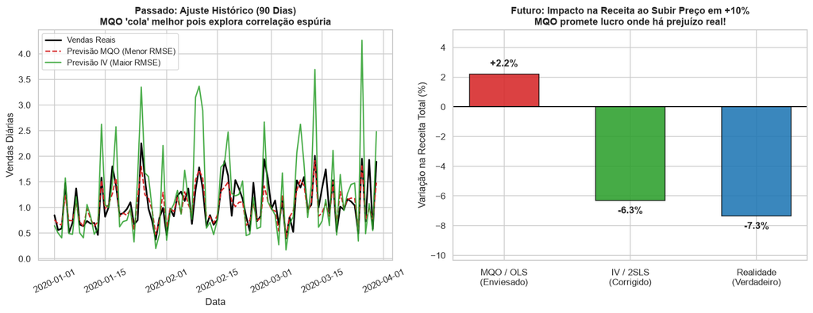

```python
# Gráfico comparativo do Trade-off: Erro no Passado vs. Decisão no Futuro (Receita)
fig, axes = plt.subplots(1, 2, figsize=(14, 5.5))

# Painel Esquerdo: Ajuste histórico (primeiros 90 dias para ficar bem nítido)
sub = dados.iloc[:90]
axes[0].plot(sub["data"], sub["vendas"], color="black", lw=2, label="Vendas Reais")
axes[0].plot(sub["data"], pred_vendas_ols.iloc[:90], color="#d62728", lw=1.6, linestyle="--", label="Previsão MQO (Menor RMSE)")
axes[0].plot(sub["data"], pred_vendas_iv.iloc[:90], color="#2ca02c", lw=1.6, alpha=0.85, label="Previsão IV (Maior RMSE)")
axes[0].set_title("Passado: Ajuste Histórico (90 Dias)\nMQO 'cola' melhor pois explora correlação espúria", fontsize=12, fontweight="bold")
axes[0].set_xlabel("Data")
axes[0].set_ylabel("Vendas Diárias")
axes[0].tick_params(axis="x", rotation=25)
axes[0].legend(fontsize=9.5)

# Painel Direito: Simulação de Impacto na Receita (+10% no preço)
labels_bar = ["MQO / OLS\n(Enviesado)", "IV / 2SLS\n(Corrigido)", "Realidade\n(Verdadeiro)"]
valores_rec = [r_ols, r_iv, r_real]
cores_bar = ["#d62728", "#2ca02c", "#1f77b4"]

bars = axes[1].bar(labels_bar, valores_rec, color=cores_bar, width=0.55, edgecolor="black", alpha=0.88)
axes[1].axhline(0, color="black", linewidth=1.2)
axes[1].set_title("Futuro: Impacto na Receita ao Subir Preço em +10%\nMQO promete lucro onde há prejuízo real!", fontsize=12, fontweight="bold")
axes[1].set_ylabel("Variação na Receita Total (%)")
axes[1].set_ylim(min(valores_rec) - 3, max(valores_rec) + 3)

for bar, val in zip(bars, valores_rec):
    va = "bottom" if val >= 0 else "top"
    offset = 0.4 if val >= 0 else -0.4
    axes[1].text(bar.get_x() + bar.get_width()/2, val + offset, f"{val:+.1f}%",
                 ha="center", va=va, fontsize=12, fontweight="bold")

plt.tight_layout()
plt.show()
```

### Entendendo o Paradoxo de Uma Vez por Todas:

1. **Por que o MQO venceu no RMSE histórico (gráfico da esquerda)?**
   - Porque no passado o preço se movia junto com o choque de demanda oculto. O MQO "trapaceia" usando o preço como um termômetro indireto do choque de demanda! Isso ajuda a *prever o passado* quando nada muda na regra de negócio, mas destrói o coeficiente causal.
   - Já o modelo IV descarta de propósito a parte contaminada do preço (ficando só com a variação do custo), o que aumenta o erro residual (RMSE) nas observações passadas, mas recupera o **efeito causal puro**.
2. **Por que o IV salvou a empresa no gráfico da direita (+10% no preço)?**
   - Quando a empresa **decide ativamente** subir o preço em +10% (uma intervenção causal), ela não está criando um choque positivo de demanda!
   - O **MQO**, enganado pelo viés, promete que a receita vai **SUBIR `+2,2%`**.
   - Se a empresa acreditar no MQO e subir o preço, a **realidade** entrega uma **QUEDA de `-7,3%` na receita** — exatamente o alerta de prejuízo que o modelo **IV / 2SLS** (`-6,3%`) havia previsto!

## 10. Conclusão e Guia de Decisão Prática

| Objetivo do Projeto | Qual Método Usar? | Por quê? |
| --- | --- | --- |
| **Previsão Pura (*Forecasting*)** sem mudança de política (ex.: prever demanda amanhã mantendo a mesma estratégia de preços) | **MQO / OLS** ou modelos de ML (XGBoost, LightGBM) | Menor variância e menor RMSE; correlações espúrias ajudam a prever se o padrão histórico não mudar. |
| **Inferência Causal e Decisão Estratégica** (ex.: definir novos preços, avaliar descontos, estimar elasticidades, políticas públicas) | **Variáveis Instrumentais (IV / 2SLS)** ou outros métodos causais | Elimina o viés de endogeneidade e responde corretamente a perguntas contrafactuais (*"o que acontece se eu mudar X?"*). |

### Referências Bibliográficas

1. **Angrist, J. D., & Pischke, J. S. (2009)**. *Mostly Harmless Econometrics: An Empiricist's Companion*. Princeton University Press.
2. **Wooldridge, J. M. (2010)**. *Econometric Analysis of Cross Section and Panel Data* (2nd ed.). MIT Press.
3. **Stock, J. H., & Watson, M. W. (2015)**. *Introduction to Econometrics*. Pearson.